# Advance Scatterplot Techniques Assignment

Mike LeVan

2025-03-12

# Introductory Data Science Course: Scatterplot Problems

## Problem 1: Custom Colors and Shapes

Use the `iris` dataset to create a scatterplot of `Sepal.Length` vs. `Sepal.Width`. Change the color of the points based on `Species` and use different shapes for each species.

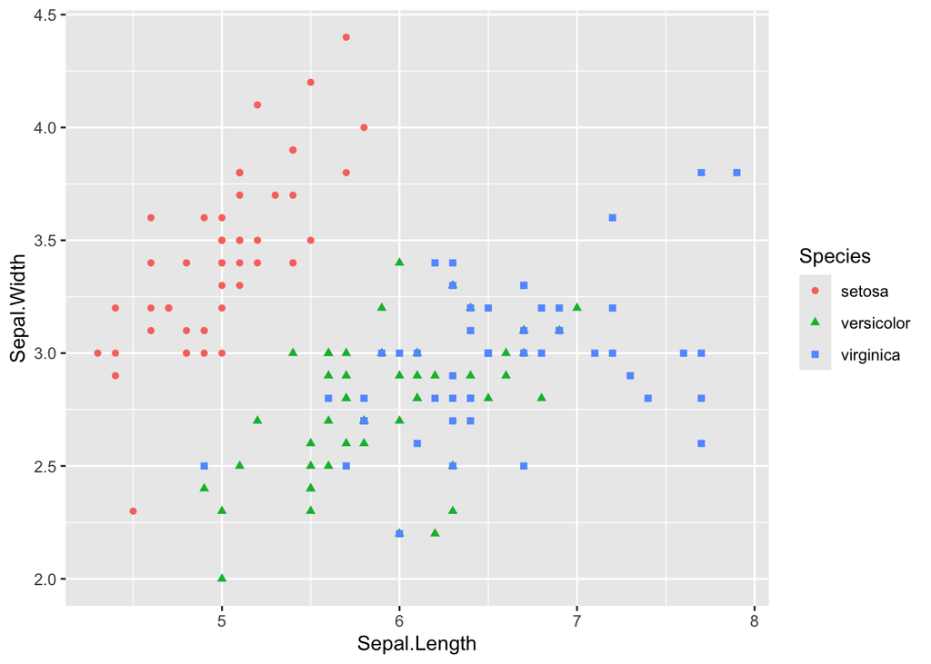

```r
# Solution
library(ggplot2)
ggplot(iris, aes(x = Sepal.Length, y = Sepal.Width, color = Species, shape = Species)) +
  geom_point()
```

## Problem 2: Size and Alpha Levels

Use the `iris` dataset to create a scatterplot of `Sepal.Length` vs. `Petal.Length`. Change the size of the points based on `Petal.Width` and set the alpha level to 0.6.

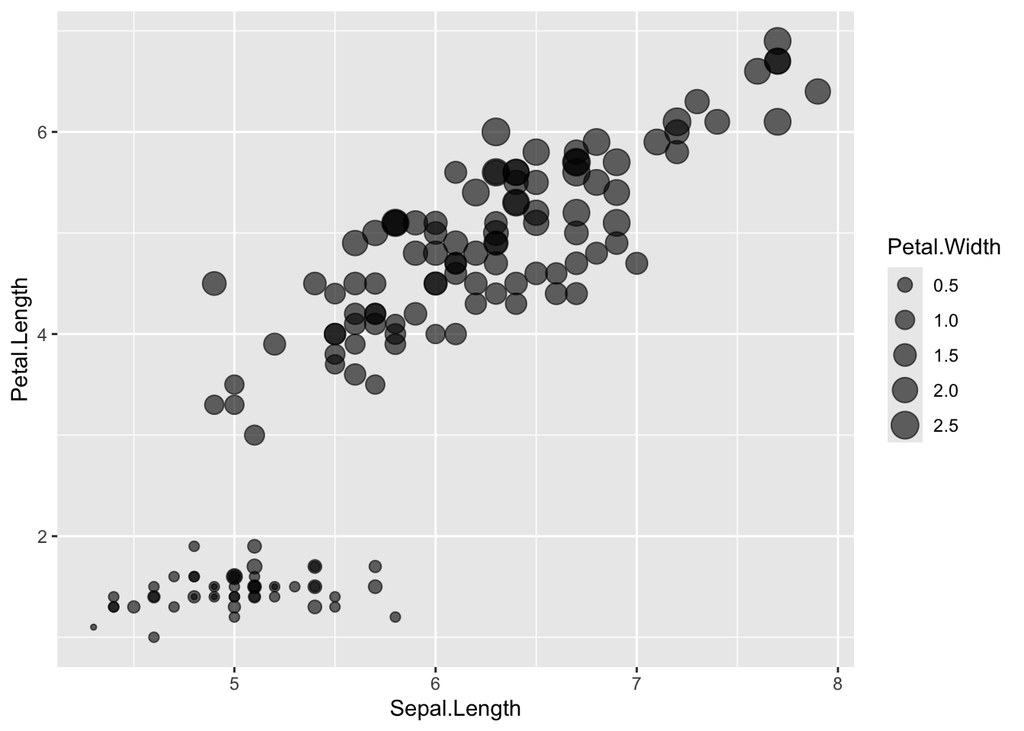

```r
# Solution
ggplot(iris, aes(x = Sepal.Length, y = Petal.Length, size = Petal.Width)) +
  geom_point(alpha = 0.6)
```

## Problem 3: Fill and Stroke

Use the `iris` dataset to create a scatterplot of `Petal.Length` vs. `Petal.Width`. Change the fill color of the points based on `Species` and add a black border (stroke) to the points.

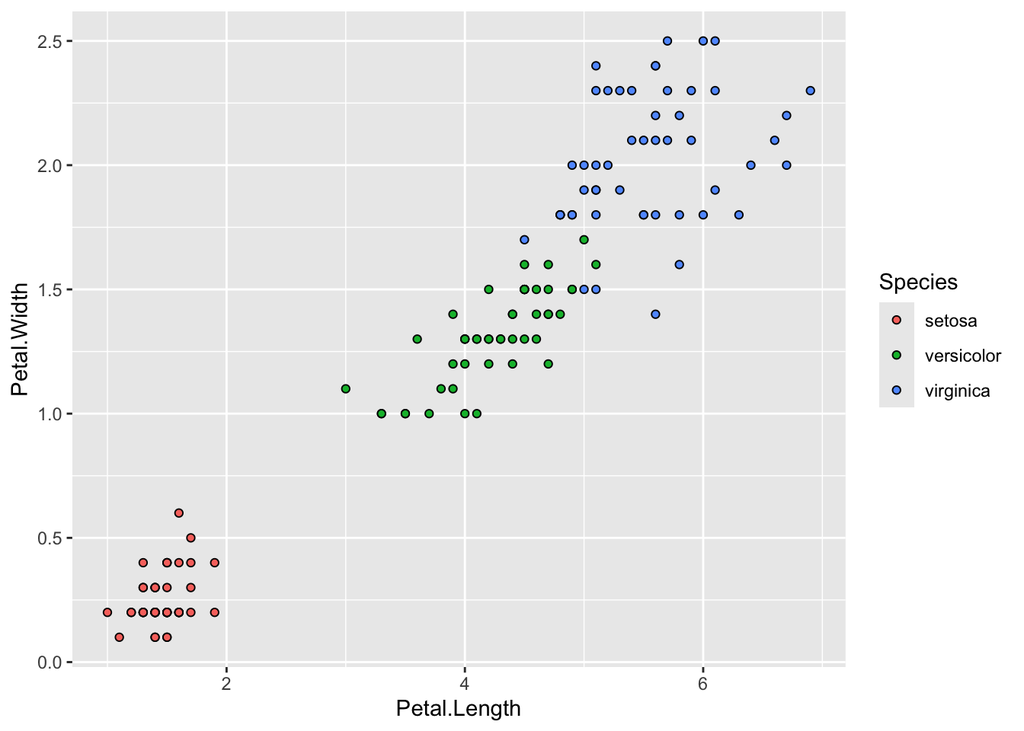

```r
# Solution
ggplot(iris, aes(x = Petal.Length, y = Petal.Width, fill = Species)) +
  geom_point(shape = 21, color = "black")
```

## Problem 4: Faceted Scatterplot (Single Variable)

Use the `iris` dataset to create a scatterplot of `Sepal.Length` vs. `Sepal.Width`. Facet the plot by `Species`.

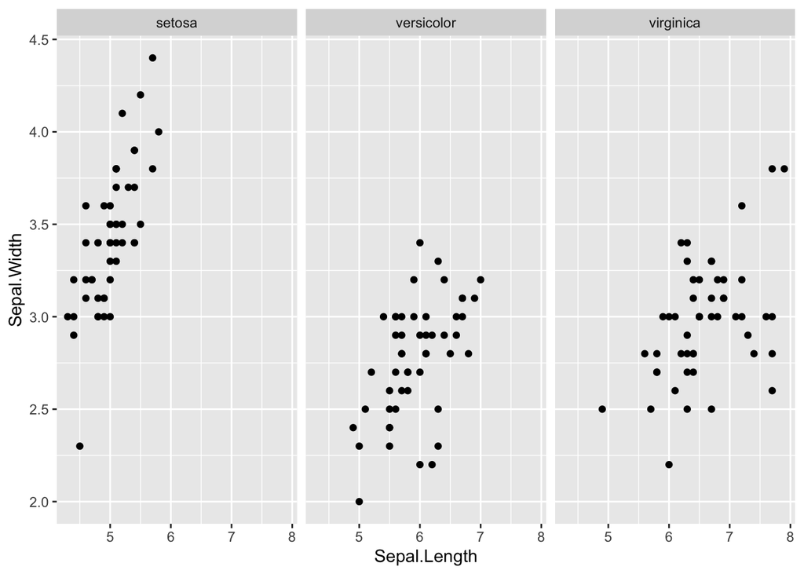

```r
# Solution
ggplot(iris, aes(x = Sepal.Length, y = Sepal.Width)) +
  geom_point() +
  facet_wrap(~ Species)
```

## Problem 5: Faceted Scatterplot (Multiple Variables)

Use the `iris` dataset to create a scatterplot of `Petal.Length` vs. `Petal.Width`. Facet the plot by `Species` and include a different color for each species.

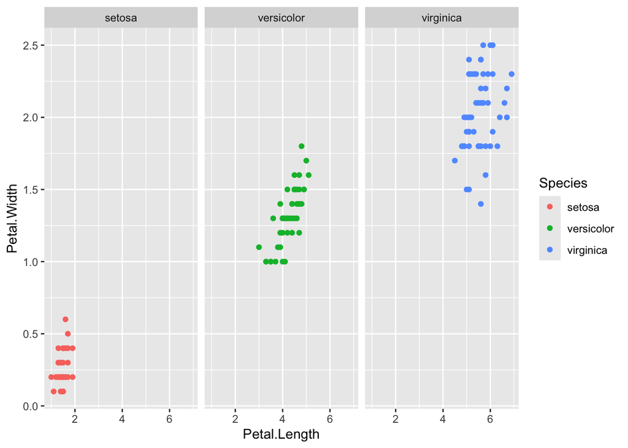

```r
# Solution
ggplot(iris, aes(x = Petal.Length, y = Petal.Width, color = Species)) +
  geom_point() +
  facet_grid(~ Species)
```

## Problem 6: Log Scale

Use the `diamonds` dataset to create a scatterplot of `carat` vs. `price`. Apply a log scale to the y-axis.

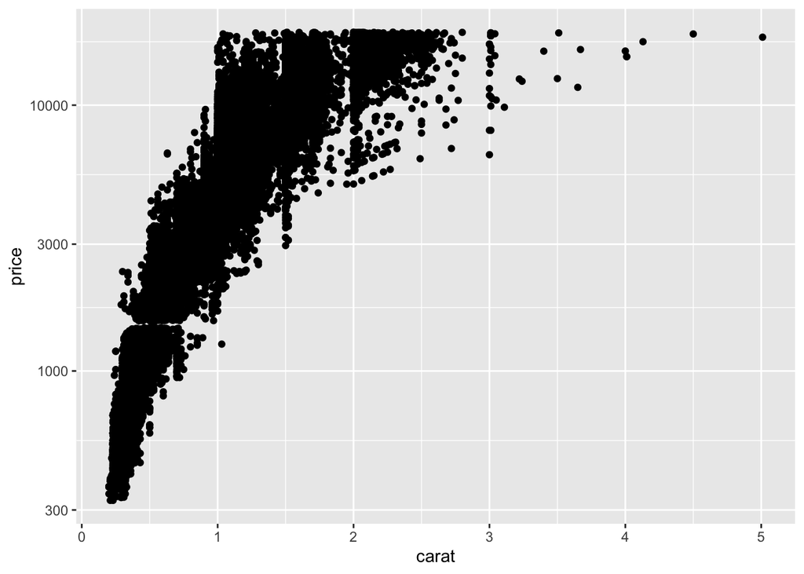

```r
# Solution
ggplot(diamonds, aes(x = carat, y = price)) +
  geom_point() +
  scale_y_log10()
```

## Problem 7: Custom Colors and Alpha

Use the `diamonds` dataset to create a scatterplot of `carat` vs. `price`. Change the color of the points based on `clarity` and set the alpha level to 0.5.

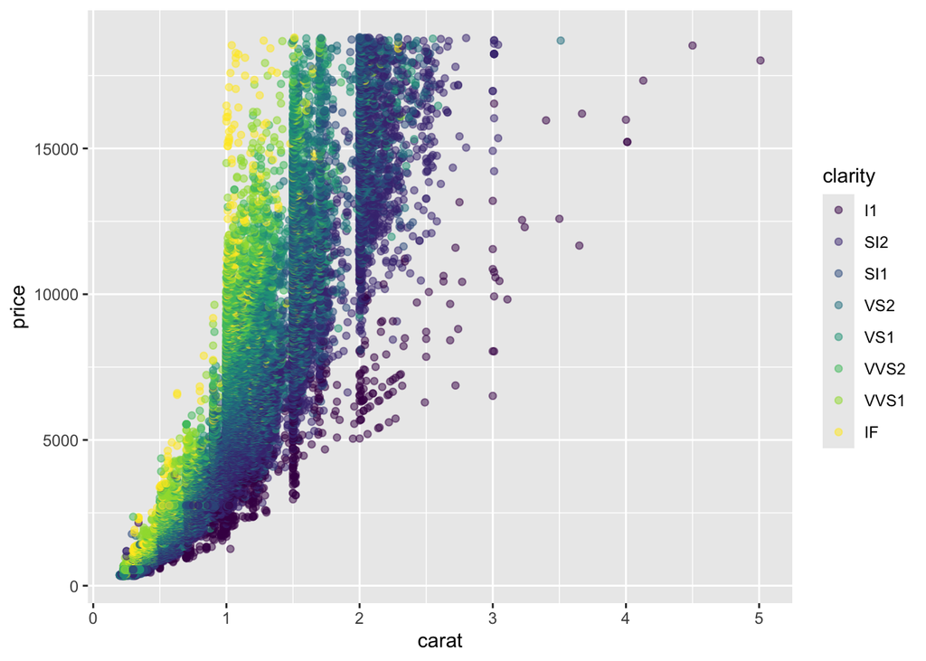

```r
# Solution
ggplot(diamonds, aes(x = carat, y = price, color = clarity)) +
  geom_point(alpha = 0.5)
```

## Problem 8: Size and Shape

Use the `ToothGrowth` dataset to create a scatterplot of `len` vs. `dose`. Change the size of the points based on `supp` and use different shapes for each supplement type.

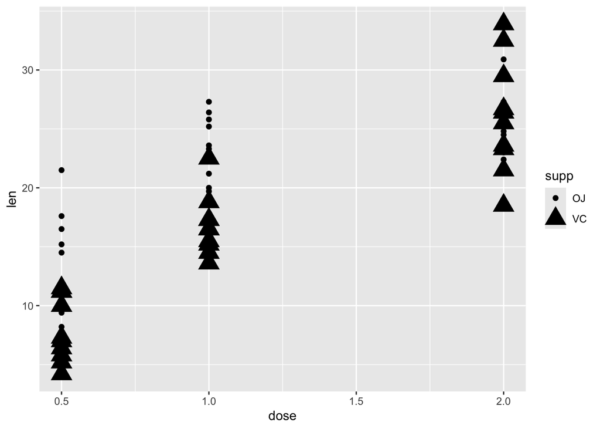

```r
# Solution
ggplot(ToothGrowth, aes(x = dose, y = len, size = supp, shape = supp)) +
  geom_point()
```

## Problem 9: Faceted Scatterplot with Custom Colors

Use the `ToothGrowth` dataset to create a scatterplot of `len` vs. `dose`. Facet the plot by `supp` and change the color of the points based on `dose`.

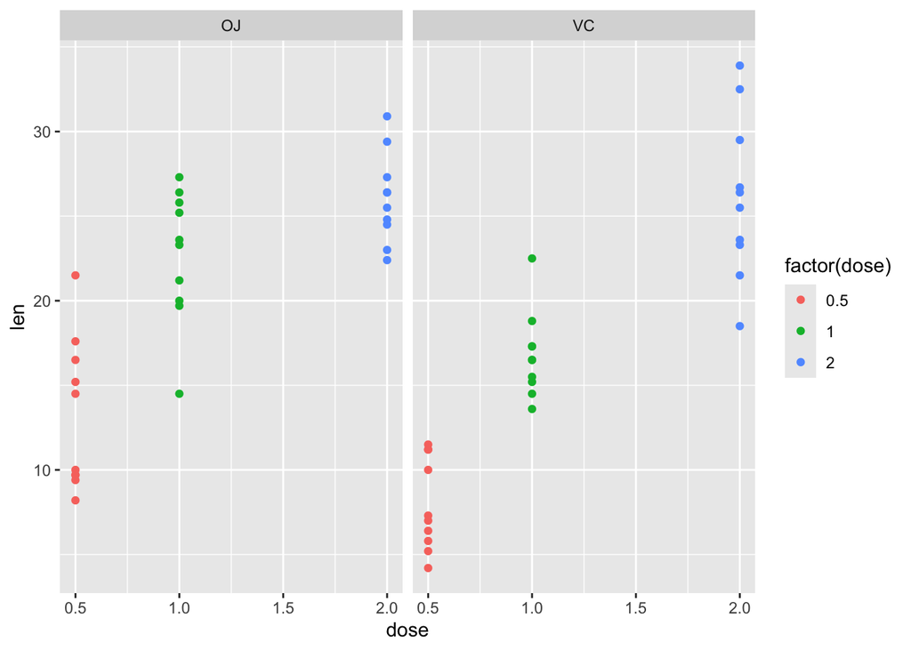

```r
# Solution
ggplot(ToothGrowth, aes(x = dose, y = len, color = factor(dose))) +
  geom_point() +
  facet_wrap(~ supp)
```

## Problem 10: Fill, Size, and Alpha

Use the `ChickWeight` dataset to create a scatterplot of `Time` vs. `weight`. Change the fill color of the points based on `Diet`, the size of the points based on `Chick`, and set the alpha level to 0.7.

[figure not shown]

```r
# Solution
ggplot(ChickWeight, aes(x = Time, y = weight, fill = factor(Diet), size = Chick)) +
  geom_point(shape = 21, alpha = 0.7)
```